# HTS Project

Author

Olga Leśkiewicz, Tomasz Medoń, Kaja Łucka

## Introduction:

Bioinformatics is a rapidly growing field, and analyses performed even a decade ago may yield different results when the same datasets are processed with current tools. In this project, we tried to replicate the results from the study [*Rab25 Is a Tumor Suppressor Gene with Anti‑angiogenic and Anti‑invasive Activities in Esophageal Squamous Cell Carcinoma*](https://aacrjournals.org/cancerres/article/72/22/6024/577982/Rab25-Is-a-Tumor-Suppressor-Gene-with)[1] from 2011*.* We wanted to see whether we would obtain similar results and if we could extract even more information from the data. Unfortunately, the exact workflow (code) used in the original study is not available, which proved how important it is to make scientific studies reproducible for future researchers.

The article we chose focuses on esophageal squamous cell carcinoma, one of the most common types of esophageal cancer, which is associated with poor prognosis and high mortality rates. This cancer develops from the squamous cells lining the esophagus and is often diagnosed at an advanced stage. The study showed down-regulation of *Rab25* in esophageal squamous cell carcinoma. Lower expression levels of this gene were associated with reduced overall survival of patients.

In the paper, high‑throughput transcriptome sequencing (RNA‑Seq) was used to identify differentially expressed genes between tumour and non‑tumour samples. From what we could find in the article, the first step of the workflow was RNA‑Seq library preparation and sequencing on an Illumina platform, followed by mapping the reads to a human reference genome. The authors then quantified transcript expression levels (counts per gene) and performed statistical analyses to identify differentially expressed genes between tumour and non‑tumour samples. After these steps, the authors carried out wet-lab validation experiments, which were not the focus of our work.

For our project, we used reads from [**BioProject PRJNA147913**](https://www.ncbi.nlm.nih.gov/bioproject/PRJNA147913), which were uploaded to the SRA archive in 2011, along with the human reference genome [**GRCh38.p14**](https://www.ncbi.nlm.nih.gov/datasets/genome/GCF_000001405.40/) from NCBI.

## Downloading data

As always, first step of analysis is downloading the data. We decided to use reads from BioProject PRJNA147913, due to the fact this reads were uploaded into SRA archive in 2011. We obtained run info from this project and then isolated SRR ids.[2]

```bash
#|eval: false
source /home/lesol/miniconda3/bin/activate
conda activate bio

esearch -db sra -query PRJNA147913 | efetch -format runinfo > runinfo.csv
cat runinfo.csv | cut -f 1 -d ',' | grep SRR | head > runids.txt

conda deactivate
```

```bash
source /home/lesol/miniconda3/bin/activate
conda activate bio

mkdir -p data
cat runids.txt | parallel -j 4 fasterq-dump -e 2 --split-files -O data {}

conda deactivate
```

Then we moved one to downloading human reference genome from NCBI. [4] [5] [6]

```bash
source /home/lesol/miniconda3/bin/activate
conda activate bio
mkdir -p reference
cd reference

datasets download genome accession GCF_000001405.40 --filename GRCh38_p14.zip --include genome,gff3,gtf

conda deactivate
```

```bash
source /home/lesol/miniconda3/bin/activate
conda activate bio
cd reference/GRCh38_p14

md5sum --check md5sum.txt

conda deactivate
```

md5sum showed that the file was not corrupted during transfer

## Quality Control

We decided to perform quality control check with two tools: FastQC and MultiQC. While FastQC generates one report per sample the MultiQC software groups any FastQC output into single report.

```bash
source /home/lesol/miniconda3/bin/activate
conda activate bio

mkdir -p QC_1/multiqc
fastqc -q -o QC_1/ data/*.fastq
multiqc -q -o QC_1/multiqc QC_1/

conda deactivate
```

The quality control showed some interesting aspects of data:

- All Samples had adapters removed before uploading them to SRA archive
- There is high level of duplication
- Two samples - SRR349743 and SR349745 have bad sequence per tile quality. The probable cause is an air bubble - due to this read some parts of chip was not read correctly
- All samples have warnings related to the ‘Per sequence GC content’ module. There is possibility of contamination with rRNA.

Unfortunately we are unable to do anything with these problems, only to take them into consideration when analyzing the data.

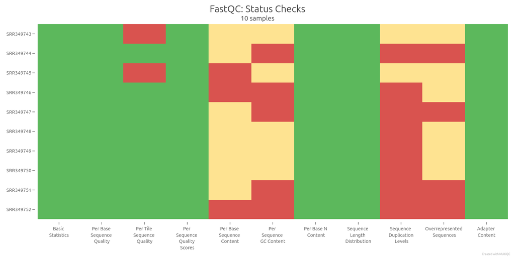

figure 1: This plot shows status for each FastQC section showing whether results seem entirely normal (green), slightly abnormal (orange) or very unusual (red). We are able to see that per base sequence content, per sequence GC content, sequence duplication levels and overrepressented sequences are abnormal or very unusual.

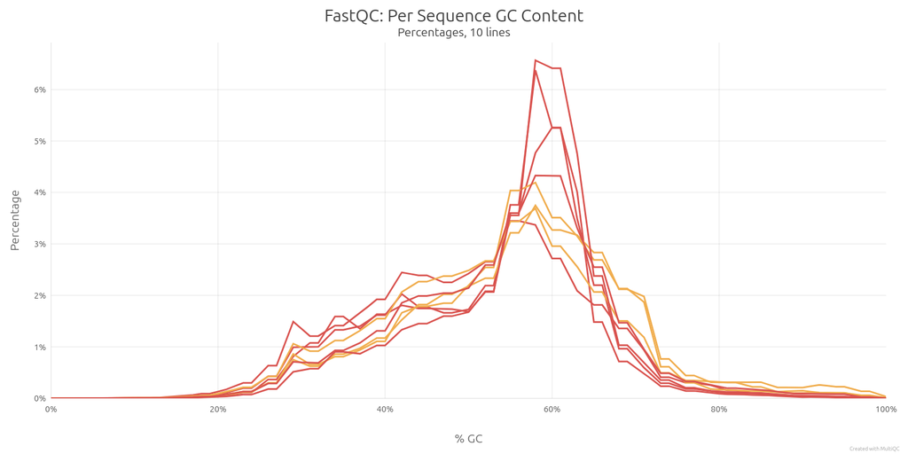

figure 2: This plot shows per sequence GC-content. We may see that it’s shape is similar to normal distribution. Unfortunately the sharp peak is observed near 58–60% GC and have wide tail around 30–50% GC. She sharp peak may indicate duplicated sequences

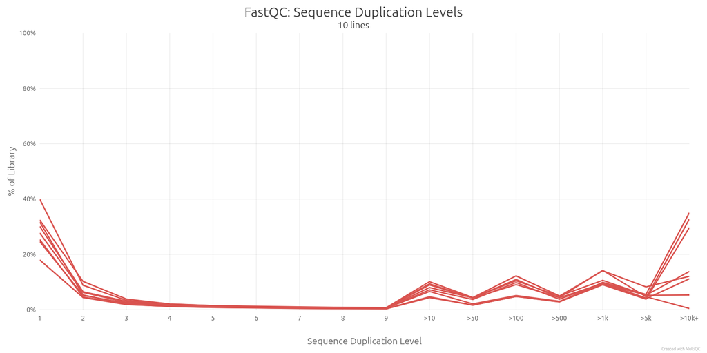

Data for our project was published in 2011, so looking at individual samples we may observe characteristic curve for older reads with Illumina.

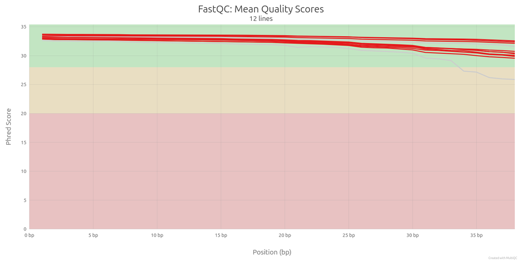

figure 4: This plot shows mean quality score of all samples. The quality drops at the end, which is typical for old RNA-seq data. The sample SR349745 have the worst quality of the set which is consisted with bad sequence per tile quality we observed earlier.

We decided to not trim our samples with Cutadapt, due to the fact that all adapters were removed prior to uploading files into SRA archive. This means this samples where probably used for analysis from the article. This approach will allow us to compere our results better.

## Mapping

We decided to use Bowtie2 for mapping reads to our reference genome.

Mapping consist of two steps:

1. indexing genome
2. mapping reads to the reference using parallel

```bash
source /home/lesol/miniconda3/bin/activate
conda activate bio

cd reference/GRCh38_p14/ncbi_dataset/data/GCF_000001405.40

bowtie2-build --threads 12 GCF_000001405.40_GRCh38.p14_genomic.fna B_ref_indx #building index

conda deactivate
```

```bash
source /home/lesol/miniconda3/bin/activate
conda activate bio

mkdir -p Bowtie_aligment
mkdir -p Bowtie_aligment Bowtie_aligment/parallel_logs

#Mapping
parallel -j 4 --results Bowtie_aligment/parallel_logs \
  bowtie2 -x reference/GRCh38_p14/ncbi_dataset/data/GCF_000001405.40/B_ref_indx \
  -U {} --threads 3 \
  -S Bowtie_aligment/{/.}.sam \
  ::: data/*.fastq
```

### Sorting and indexing bam files

The final step in processing the mapping files was sorting and indexing the files using the samtools program.

```bash
source /Users/tomek/miniconda3/bin/activate
conda activate bio

mkdir -p mapped/parallel_logs

parallel -j 4 --results mapped/parallel_logs \
  "samtools view -b {} |
  samtools sort -o mapped/{/.}_sorted.bam && samtools index mapped/{/.}_sorted.bam" \
::: Bowtie_aligment/*.sam
```

## Differential gene expression (DGE) analysis

### DESeq2

For the differential gene expression (DGE) analysis, we applied the **DESeq2** package (version 1.50.2), which is the current publication standard. DESeq2 utilizes a Negative Binomial generalized linear model, which accounts for the overdispersed nature of discrete sequencing counts. To improve the reliability of the results, the package applies dispersion shrinkage to stabilize variance estimation - a crucial step for experiments with limited biological replicates.

We started by downloading the Series Matrix File corresponding to the previously downloaded dataset.

```r
library(GEOquery)
gse <- getGEO("GSE32424", GSEMatrix=TRUE)
```

The downloaded file was used to compile a metadata table.

```r
raw_metadata <- gse[["GSE32424_series_matrix.txt.gz"]]@phenoData@data[["characteristics_ch1"]]
group_names <- gsub(".*: ", "", raw_metadata)
groups <- as.factor(group_names)
metadata <- pData(phenoData(gse[[1]]))[c('geo_accession','characteristics_ch1')]
metadata$characteristics_ch1 <- gsub(".*: ", "", metadata$characteristics_ch1)
metadata <- data.frame(metadata, row.names = 1)
metadata
```

The file did not contain Run IDs from the SRA database, hence we used the rentrez package to convert GSM IDs.

```r
library(rentrez)
gsm_to_srr <- function(gsm_id) {
  search_res <- entrez_search(db = "sra", term = gsm_id)
  info <- entrez_summary(db = "sra", id = search_res$ids)
  srr_id <- gsub(".*acc=\"([^\"]+)\".*", "\\1", info$runs)
  return(srr_id)
}

rownames(metadata) <- sapply(rownames(metadata), gsm_to_srr)
metadata
```

### **DESeqDataSet (DDS)**

The previously obtained BAM files were processed to generate a count matrix, which was then used to construct a DDS object. This object integrates the raw count data with the experimental metadata and the design formula required for downstream statistical analysis.

```r
library(Rsubread)

bam_files <- list.files("mapped", pattern = "_sorted.bam$", full.names = TRUE)
gtf_path <- 'reference/GRCh38_p14/ncbi_dataset/data/GCF_000001405.40/genomic.gtf'

counts <- featureCounts(files = bam_files,
                        annot.ext = gtf_path,
                        isGTFAnnotationFile = TRUE,
                        GTF.featureType = "exon",
                        GTF.attrType = "gene_id",
                        isPairedEnd = F,
                        nthreads = 4,
                        allowMultiOverlap = T)
```

```r
count_matrix <- counts$counts
colnames(count_matrix) <- gsub("_sorted.bam", "", colnames(count_matrix))
```

```r
library(DESeq2)
dds <- DESeqDataSetFromMatrix(countData = count_matrix, colData = metadata, design= ~ characteristics_ch1)
dds <- DESeq(dds)
```

### PCA

To assess the similarity within biological repetition groups and the differences between groups, we used PCA.

```r
norm_counts <- DESeq2::counts(dds, normalized = T)
```

```r
library(dplyr)

to_PCA <- norm_counts %>% t()
pca <- prcomp(to_PCA)

pca_metadata <- metadata %>% tibble::rownames_to_column(var ="SAMPLE")

pca_plot <-
  as.data.frame(pca$x) %>%
  tibble::rownames_to_column(var ="SAMPLE") %>%
  left_join(pca_metadata, by = "SAMPLE")
```

```r
library(ggplot2)

ggplot(pca_plot)+
  geom_point(mapping = aes(x = PC1,y = PC2,col = characteristics_ch1),size = 3)+
  labs(x = percentage_variance_explained[1],y = percentage_variance_explained[2])
```

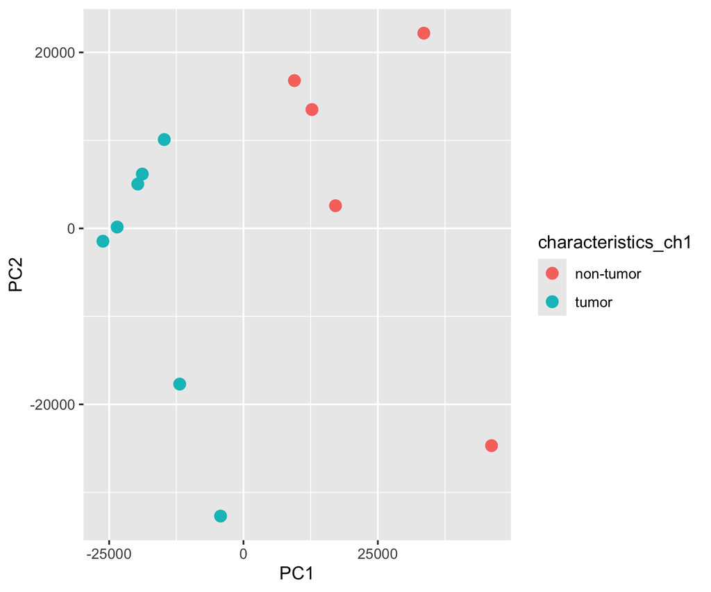

figure 5: The plot shows a clear separation of groups along the first principal component (PC1). Tumor samples (blue) are clustered on the left side of the 0 axis, while non-tumor samples (red) are clustered on the right.

The arrangement of samples indicates a strong biological signal — the difference between tumor and healthy tissue is the main factor differentiating these samples.

### Volcano plot

Finally, we created a volcano plot illustrating gene up- and downregulation.

```r
library(ggplot2)

dds_results <- results(dds, contrast = c("characteristics_ch1","tumor","non-tumor"), alpha = 0.01)
dds_results <- as.data.frame(dds_results)

ggplot(dds_results)+
  geom_point(mapping = aes(x=log2FoldChange, y=-log10(padj)))+
  theme_bw()+
  geom_vline(xintercept = c(-2,2),linetype = "dotted")
```

```r
library(dplyr)
downregulated <- row.names(filter(dds_results, padj < 0.01, log2FoldChange < -2))
upregulated <- row.names(filter(dds_results, padj < 0.01, log2FoldChange > 2))
```

We filtered by standard values:

- down-regulated genes (padj < 0.01, log2FoldChange < -2)
- up-regulated genes (padj < 0.01, log2FoldChange > 2).

We obtained a list of 474 downregulated genes and 960 upregulated genes.

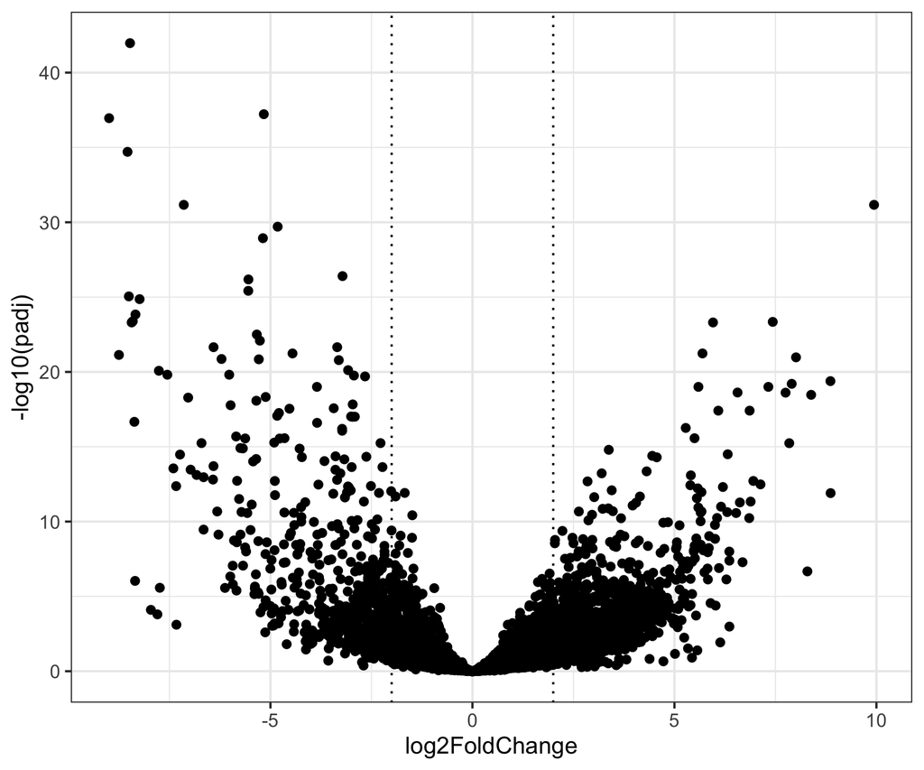

figure 6: Volcano plot illustrating differential gene expression

## Statistics comparison with the article

```r
names <- c("Current study", "Tong, Man et al.")
Values <- c(sum(rowSums(counts(dds)) > 0), 14351)

barplot(Values, main = 'Number of represented genes', names.arg = names, ylab = 'Number of genes', col = 'steelblue2')
```

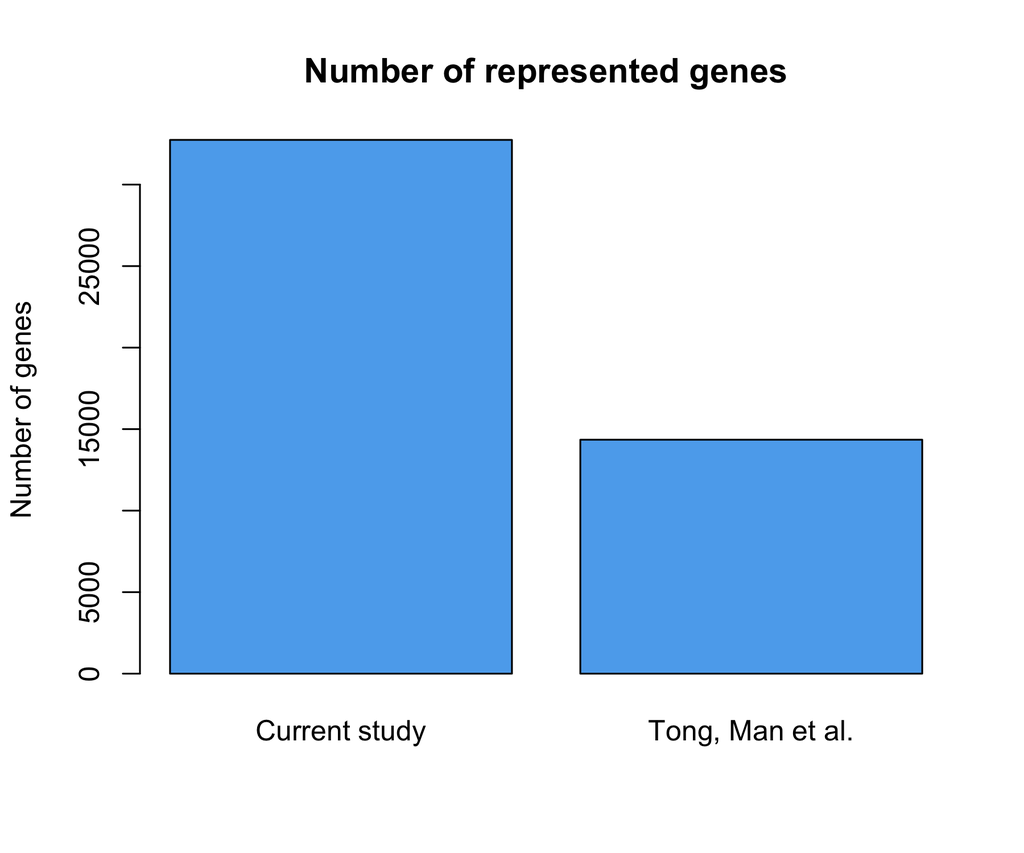

figure 7: The plot shows double increase in the number of genes included in the current analysis compared to the article. The original analysis was based on the NCBI Build 37.1 genome, which contained 26,419 meta-features, while GRCh38.2 contains 50,116. The increase is likely due to the inclusion of thousands of newly cataloged sequences.

```r
Values <- c(sum(rowSums(counts(dds)) >= 10)/nrow(counts(dds))*100, 42)
barplot(Values, main = '% of the total number of genes in the reference database \n with at least 10 exon reads', names.arg = names, ylab = '%', col = 'steelblue2', ylim = c(0, 100))
```

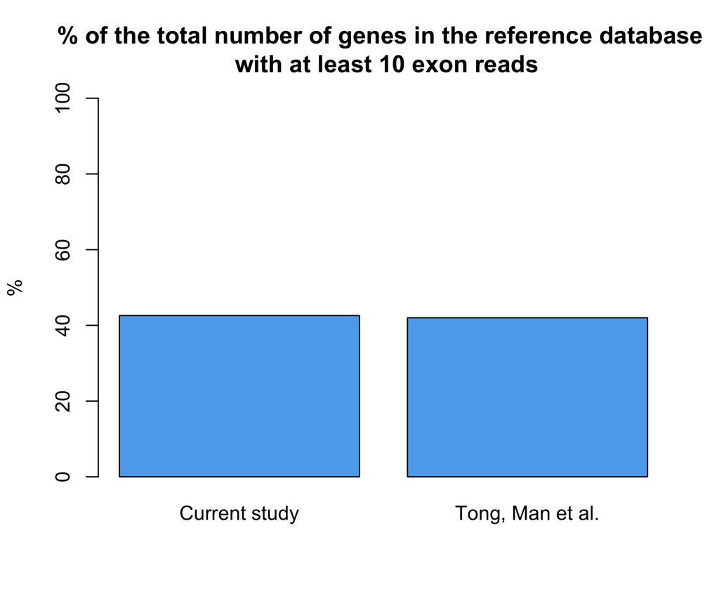

figure 8: Despite the increase in the number of genes in the reference database, the percentage of genes actually detected remained almost identical in both studies. This consistency indicates that the sequencing depth allows for the capture of a similar fraction of the transcriptome.

```r
colors = c('tomato2', "steelblue2")
names <- c("Current study", "Tong, Man et al.")
regions <- c("Down-regulated", "Up-regulated")

Values <- matrix(c(length(downregulated), 132,
                   length(upregulated), 1598),
                nrow = 2, ncol = 2, byrow = TRUE)

barplot(Values, main = "Number of detected Differentially Expressed Genes", names.arg = names,
                        ylab = "Number of genes",
                        col = colors, beside = TRUE)

legend("topleft", regions, cex = 0.7, fill = colors)
```

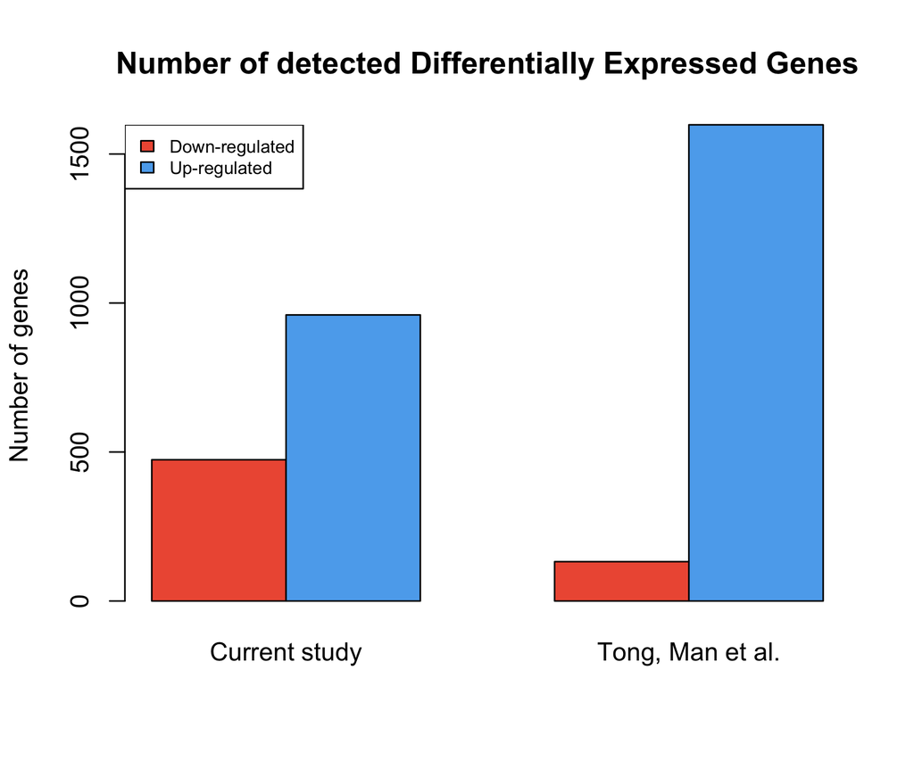

## Functional analysis (GO terms)

### DAVID

As there were problems with RDAVIDWebService R library (it was unavailable) and DAVID API (could not esablish connection), we decided to perform analysis in DAVID manually (which we know is a bad practice due to limited reproducibility). Pathway enrichment analysis was performed separately for upregulated and downregulated genes.

The steps taken (analogically for downregulated genes):

1. Go to https://davidbioinformatics.nih.gov/tools.jsp
2. **Step 1: Enter Gene List** -`B:Choose From a File` “up.txt”
3. **Step 2: Select Identifier** - `OFFICIAL_GENE_SYMBOL`
4. **Step 2a: Select species** - `Homo sapiens`
5. **Step 3: List Type** - `Gene List`
6. **Step 4: Submit List**
7. **Functional Annotation Tool** (save every chart a CSV file for easier plotting)
   - **-> Gene_Ontology** -> `GOTERM BP DIRECT` -> `CHART` -> EASE Threshold: 0.01, Count Threshold: 10
   - **-> Gene_Ontology** -> `GOTERM CC DIRECT` -> `CHART` -> EASE Threshold: 0.01, Count Threshold: 10
   - **-> Gene_Ontology** -> `GOTERM MF DIRECT` -> `CHART` -> EASE Threshold: 0.01, Count Threshold: 10
   - **-> Pathways** -> `KEGG PATHWAY` -> `CHART` -> EASE Threshold: 0.01, Count Threshold: 10

This youtube video was tremendously helpful when working with DAVID: https://youtu.be/EuCH5mqRylE?si=PGmqrgU2286MhFte

```r
library(ggplot2)
library(dplyr)

bp_up <- read.table("DAVID/upregulated/bp.csv", header=TRUE, sep = ",")
cc_up <- read.table("DAVID/upregulated/cc.csv", header=TRUE, sep = ",")
mf_up <- read.table("DAVID/upregulated/mf.csv", header=TRUE, sep = ",")
kegg_up <- read.table("DAVID/upregulated/kegg.csv", header=TRUE, sep = ",")

bp_dn <- read.table("DAVID/downregulated/bp.csv", header=TRUE, sep = ",")
cc_dn <- read.table("DAVID/downregulated/cc.csv", header=TRUE, sep = ",")
mf_dn <- read.table("DAVID/downregulated/mf.csv", header=TRUE, sep = ",")
kegg_dn <- read.table("DAVID/downregulated/kegg.csv", header=TRUE, sep = ",")


# I choose 5 with most genes
all_tables_up <- list(BP = bp_up, CC = cc_up, MF = mf_up, KEGG = kegg_up)
all_tables_dn <- list(BP = bp_dn, CC = cc_dn, MF = mf_dn, KEGG = kegg_dn)

get_top5 <- function(df)
{
  df %>%
    arrange(desc(Count)) %>%
    slice(1:5)
}

top5_up <- lapply(all_tables_up, get_top5)
top5_dn <- lapply(all_tables_dn, get_top5)

generate_plot <- function(top5, y, title)
{
  plot_bp_up <- ggplot(top5) +
    aes(x = Count, y = reorder(Term, Count), fill = Benjamini) +
    geom_col() +
    scale_fill_gradient(low = "red", high = "blue") +
    labs(
      x = "Number of genes",
      y = y, # "GO Term"
      fill = "Adjusted p-value (Benjamini)",
      title = title #"Top 5 enriched GO terms"
    ) +
    theme_light(base_size = 14) +
    theme(
      axis.text.y = element_text(size = 12),
      plot.title = element_text(hjust = 0.5)
    )
}

ggsave("Plots/DAVID/bp_up.png",
       plot = generate_plot(top5_up$BP, "Biological Processes", "Top 5 enriched Biological Processes"),
       width = 12, height = 6, dpi = 600)
ggsave("Plots/DAVID/cc_up.png",
       plot = generate_plot(top5_up$CC, "Cellular Components", "Top 5 enriched Cellular Components"),
       width = 12, height = 6, dpi = 600)
ggsave("Plots/DAVID/mf_up.png",
       plot = generate_plot(top5_up$MF, "Molecular Functions", "Top 5 enriched Molecular Functions"),
       width = 12, height = 6, dpi = 600)
ggsave("Plots/DAVID/kegg_up.png",
       plot = generate_plot(top5_up$KEGG, "KEGG pathways", "Top 5 KEGG pathways"),
       width = 12, height = 6, dpi = 600)

ggsave("Plots/DAVID/bp_dn.png",
       plot = generate_plot(top5_dn$BP, "Biological Processes", "Top 5 enriched Biological Processes"),
       width = 12, height = 6, dpi = 600)
ggsave("Plots/DAVID/cc_dn.png",
       plot = generate_plot(top5_dn$CC, "Cellular Components", "Top 5 enriched Cellular Components"),
       width = 12, height = 6, dpi = 600)
ggsave("Plots/DAVID/mf_dn.png",
       plot = generate_plot(top5_dn$MF, "Molecular Functions", "Top 5 enriched Molecular Functions"),
       width = 12, height = 6, dpi = 600)
ggsave("Plots/DAVID/kegg_dn.png",
       plot = generate_plot(top5_dn$KEGG, "KEGG pathways", "Top 5 KEGG pathways"),
       width = 12, height = 6, dpi = 600)
```

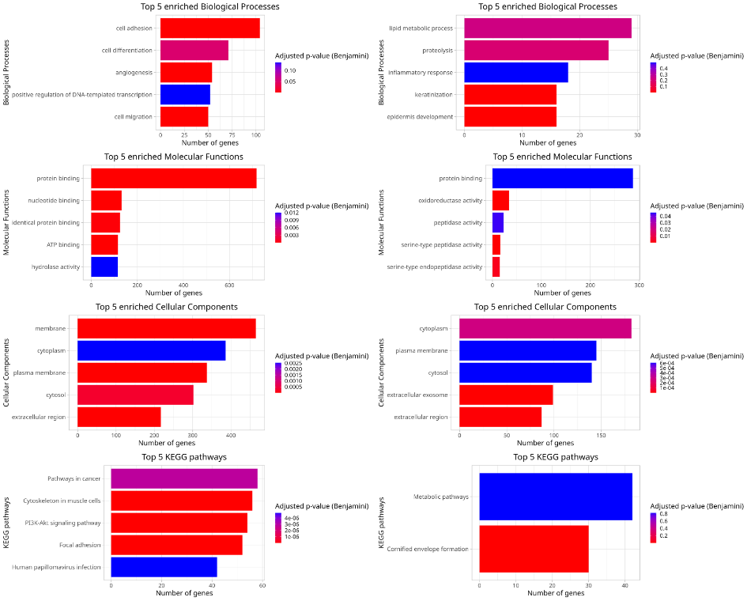

Figure 10: Plots created with code above from data generated with DAVID. All plots except the last one display the 5 terms with the highest enrichment. Higher-quality versions are available on our GitHub.

### enrichGO

```r
# importing data from TXT files
downregulated <- read.table("down.txt")
upregulated <- read.table("up.txt")
down_vec <- as.character(downregulated$V1)
up_vec <- as.character(upregulated$V1)

# importing data from a CSV file - creating gene universe
counts_matrix <- read.table("counts_matrix.csv", header=TRUE, sep = ",", row.names=1)
gene_universe <- rownames(counts_matrix)  # all detected genes
```

```r
library(clusterProfiler)
library(org.Hs.eg.db)  # human (patient-derived) samples

enrich <- function(gene, ont){
  enrichGO(gene = gene,
           universe = gene_universe,
           OrgDb = "org.Hs.eg.db",
           pAdjustMethod = "BH",
           pvalueCutoff = 0.01,
           qvalueCutoff = 0.01,
           readable = T,
           keyType = "SYMBOL",
           ont = ont) # "Biological Processes" / "Molecular Functions" / "Cellular Components"
}
up_vec_BP <- enrich(up_vec, "BP")
up_vec_MF <- enrich(up_vec, "MF")
up_vec_CC <- enrich(up_vec, "CC")

down_vec_BP <- enrich(down_vec, "BP")
down_vec_MF <- enrich(down_vec, "MF")
down_vec_CC <- enrich(down_vec, "CC")
```

```r
library(enrichplot)
dotplot(up_vec_BP)
dotplot(up_vec_MF)
dotplot(up_vec_CC)

dotplot(down_vec_BP)
dotplot(down_vec_MF)
dotplot(down_vec_CC)
```

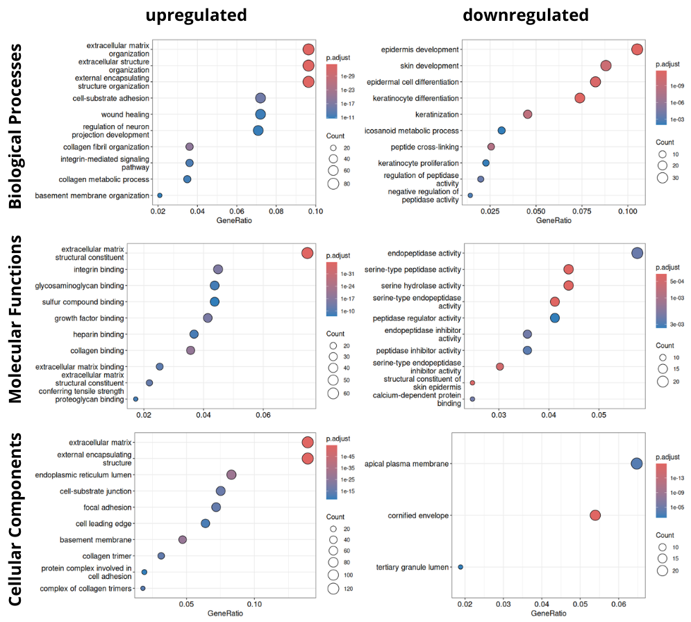

Figure 11: Plots created using enrichGO and visualised with enrichplot. All plots except the last one display the 10 terms with the highest enrichment. Higher-quality versions are available on our GitHub.

Among upregulated genes, most enriched ones were connected to extracellular matrix. Interestingly, downregulated Biological Processes were clearly connected to squamous carcinoma.

### Comparison with the article

In the article it is said that pathway enrichment analysis “found the deregulated genes to be commonly associated with a number of cancer-related pathways”. Two most enriched pathways were related to integrin signaling.

In our analysis with DAVID, we also observed that the deregulated genes are associated with cancer. However, we did not find evidence supporting their specific involvement in integrin signaling.

Interestingly, using enrichGO, we found that upregulated genes are associated with integrin binding in molecular functions and with the integrin-mediated signaling pathway in biological processes.

DAVID and enrichGO returned different GO terms, but in both cases the results matched the findings from the article. DAVID and enrichGO work diferently: DAVID uses predefined gene sets and clusters to give a more general view, while enrichGO tests each GO term statistically and is more precise. Using both tools made the analysis more complete in our view.

## Conclusion:

During this project we were able to observed progress that bioinformatics tools and data bases have made in last 15 years.

The results may differ due to tools version, genome reference bias and pipelines. This draws two important conclusion:

- always document your pipeline and tool versions. Try to make documentation as easy to find as possible - this ensures reproducible results and allows better comparison
- The bioinformatics is computational science field. It is important to validate results experimentally if possible.

  With Bioinformatics methods we are able to crunch big amounts of data, see bigger picture and narrow down the search area for many scientific questions but the wet lab is still necessary part of most science experiments. [7] [8]

### Versions of programs used:

entrez-direct 24.0

fasterq-dump : 3.2.1

md5sum (GNU coreutils): 9.4

bowtie2-align-s version: 2.5.4

STAR: 2.7.11b

samtools 1.22.1

**disclaimer**: during work on this project we used ChatGPT 5.2 version - this AI tool was used for translating to polish part of documentation, managing YAML options and debugging code. Examples of used prompt can be found in file:  
AI_usage.txt

## Contributions:

This project was created by three students:

- Olga Leśkiewicz - created plan of the project, performed quality check, mapping and prepared design of the slides show
- Kaja Łucka - she wrote an introduction, performed enrichment analysis with DAVID, KEGG and GEO
- Tomasz Medoń - meta-data specialist, performed DEG analysis and compered its results to original study

All of the members added their parts to the slides show of presentation and participated in looking for the right aritcle

## Citations:

[1] Tong, Man, Kwok Wah Chan, Jessie Y.J. Bao, Kai Yau Wong, Jin-Na Chen, Pak Shing Kwan, Kwan Ho Tang, et al. 2012. ‘Rab25 Is a Tumor Suppressor Gene with Antiangiogenic and Anti-Invasive Activities in Esophageal Squamous Cell Carcinoma’. *Cancer Research* 72(22): 6024–35. doi:10.1158/0008-5472.CAN-12-1269.

[2] Download a Genome Data Package’. https://www.ncbi.nlm.nih.gov/datasets/docs/v2/how-tos/genomes/download-genome/ (January 28, 2026).

[3] Download and Install’. https://www.ncbi.nlm.nih.gov/datasets/docs/v2/command-line-tools/download-and-install/ (January 28, 2026).

[4] Guide to Linux Parallel Command With Examples | Baeldung on Linux’. 2024. https://www.baeldung.com/linux/parallel-command-tutorial (January 28, 2026).

[5] Lesson 6: Downloading Data from the SRA - Bioinformatics for Beginners 2022’. https://bioinformatics.ccr.cancer.gov/docs/b4b/Module1_Unix_Biowulf/Lesson6/ (January 28, 2026).

[6] O’Leary NA, Cox E, Holmes JB, Anderson WR, Falk R, Hem V, Tsuchiya MTN, Schuler GD, Zhang X, Torcivia J, Ketter A, Breen L, Cothran J, Bajwa H, Tinne J, Meric PA, Hlavina W, Schneider VA. [Exploring and retrieving sequence and metadata for species across the tree of life with NCBI Datasets.](https://www.nature.com/articles/s41597-024-03571-y) Sci Data. 2024 Jul 5;11(1):732. doi: 10.1038/s41597-024-03571-y. PMID: 38969627; PMCID: PMC11226681.

[7] Clarke, Robert, John J Tyson, Ming Tan, William T Baumann, Lu Jin, Jianhua Xuan, and Yue Wang. 2019. ‘Systems Biology: Perspectives on Multiscale Modeling in Research on Endocrine-Related Cancers’. Endocrine-related cancer 26(6): R345–68. Doi:10.1530/ERC-18-0309.

[8] Jafari, Mohieddin, Yuanfang Guan, David C. Wedge, and Naser Ansari-Pour. 2021. ‘Re-Evaluating Experimental Validation in the Big Data Era: A Conceptual Argument’. Genome Biology 22: 71. doi:10.1186/s13059-021-02292-4.